# Optimal Treatment Analysis

## Outcome Variable

**Outcome Variable:** whz

## Predictor Variables

**Intervention Variable:** hhwealth_quart

**Adjustment Set:**

- arm
- sex
- W_mage
- meducyrs
- feducyrs
- W_gagebrth
- W_birthwt
- W_birthlen
- W_nchldlt5
- W_parity
- delta_W_mage
- delta_meducyrs
- delta_feducyrs
- delta_W_gagebrth
- delta_W_birthwt
- delta_W_birthlen
- delta_W_nchldlt5
- delta_W_parity

## Stratifying Variables

The analysis was stratified on these variable(s):

- agecat
- studyid
- country

## Data Summary

| agecat | studyid | country | hhwealth_quart | n_cell | n |
| --- | --- | --- | --- | --- | --- |
| Birth | ki0047075b-MAL-ED | BANGLADESH | Wealth Q4 | 21 | 76 |
| Birth | ki0047075b-MAL-ED | BANGLADESH | Wealth Q1 | 17 | 76 |
| Birth | ki0047075b-MAL-ED | BANGLADESH | Wealth Q2 | 18 | 76 |
| Birth | ki0047075b-MAL-ED | BANGLADESH | Wealth Q3 | 20 | 76 |
| Birth | ki0047075b-MAL-ED | INDIA | Wealth Q4 | 11 | 54 |
| Birth | ki0047075b-MAL-ED | INDIA | Wealth Q1 | 17 | 54 |
| Birth | ki0047075b-MAL-ED | INDIA | Wealth Q2 | 15 | 54 |
| Birth | ki0047075b-MAL-ED | INDIA | Wealth Q3 | 11 | 54 |
| Birth | ki0047075b-MAL-ED | NEPAL | Wealth Q4 | 9 | 30 |
| Birth | ki0047075b-MAL-ED | NEPAL | Wealth Q1 | 8 | 30 |
| Birth | ki0047075b-MAL-ED | NEPAL | Wealth Q2 | 6 | 30 |
| Birth | ki0047075b-MAL-ED | NEPAL | Wealth Q3 | 7 | 30 |
| Birth | ki0047075b-MAL-ED | PERU | Wealth Q4 | 10 | 36 |
| Birth | ki0047075b-MAL-ED | PERU | Wealth Q1 | 9 | 36 |
| Birth | ki0047075b-MAL-ED | PERU | Wealth Q2 | 9 | 36 |
| Birth | ki0047075b-MAL-ED | PERU | Wealth Q3 | 8 | 36 |
| Birth | ki0047075b-MAL-ED | SOUTH AFRICA | Wealth Q4 | 15 | 61 |
| Birth | ki0047075b-MAL-ED | SOUTH AFRICA | Wealth Q1 | 16 | 61 |
| Birth | ki0047075b-MAL-ED | SOUTH AFRICA | Wealth Q2 | 14 | 61 |
| Birth | ki0047075b-MAL-ED | SOUTH AFRICA | Wealth Q3 | 16 | 61 |
| Birth | ki0047075b-MAL-ED | TANZANIA, UNITED REPUBLIC OF | Wealth Q4 | 5 | 23 |
| Birth | ki0047075b-MAL-ED | TANZANIA, UNITED REPUBLIC OF | Wealth Q1 | 6 | 23 |
| Birth | ki0047075b-MAL-ED | TANZANIA, UNITED REPUBLIC OF | Wealth Q2 | 7 | 23 |
| Birth | ki0047075b-MAL-ED | TANZANIA, UNITED REPUBLIC OF | Wealth Q3 | 5 | 23 |
| Birth | ki1000108-CMC-V-BCS-2002 | INDIA | Wealth Q4 | 31 | 88 |
| Birth | ki1000108-CMC-V-BCS-2002 | INDIA | Wealth Q1 | 12 | 88 |
| Birth | ki1000108-CMC-V-BCS-2002 | INDIA | Wealth Q2 | 20 | 88 |
| Birth | ki1000108-CMC-V-BCS-2002 | INDIA | Wealth Q3 | 25 | 88 |
| Birth | ki1000108-IRC | INDIA | Wealth Q4 | 79 | 343 |
| Birth | ki1000108-IRC | INDIA | Wealth Q1 | 90 | 343 |

[output cut: 158 more lines]

The following strata were considered:

- agecat: 24 months, studyid: ki0047075b-MAL-ED, country: BANGLADESH
- agecat: 24 months, studyid: ki0047075b-MAL-ED, country: INDIA
- agecat: 24 months, studyid: ki0047075b-MAL-ED, country: NEPAL
- agecat: 24 months, studyid: ki0047075b-MAL-ED, country: PERU
- agecat: 24 months, studyid: ki0047075b-MAL-ED, country: SOUTH AFRICA
- agecat: 24 months, studyid: ki0047075b-MAL-ED, country: TANZANIA, UNITED REPUBLIC OF
- agecat: 24 months, studyid: ki1000108-CMC-V-BCS-2002, country: INDIA
- agecat: 24 months, studyid: ki1000108-IRC, country: INDIA
- agecat: 24 months, studyid: ki1017093b-PROVIDE, country: BANGLADESH
- agecat: 24 months, studyid: ki1066203-TanzaniaChild2, country: TANZANIA, UNITED REPUBLIC OF
- agecat: 24 months, studyid: ki1113344-GMS-Nepal, country: NEPAL
- agecat: 24 months, studyid: ki1114097-CONTENT, country: PERU
- agecat: 24 months, studyid: ki1135781-COHORTS, country: GUATEMALA
- agecat: 24 months, studyid: ki1135781-COHORTS, country: PHILIPPINES
- agecat: 24 months, studyid: ki1148112-LCNI-5, country: MALAWI
- agecat: 24 months, studyid: kiGH5241-JiVitA-3, country: BANGLADESH
- agecat: 24 months, studyid: kiGH5241-JiVitA-4, country: BANGLADESH
- agecat: 6 months, studyid: ki0047075b-MAL-ED, country: BANGLADESH
- agecat: 6 months, studyid: ki0047075b-MAL-ED, country: INDIA
- agecat: 6 months, studyid: ki0047075b-MAL-ED, country: NEPAL
- agecat: 6 months, studyid: ki0047075b-MAL-ED, country: PERU
- agecat: 6 months, studyid: ki0047075b-MAL-ED, country: SOUTH AFRICA
- agecat: 6 months, studyid: ki0047075b-MAL-ED, country: TANZANIA, UNITED REPUBLIC OF
- agecat: 6 months, studyid: ki1000108-CMC-V-BCS-2002, country: INDIA
- agecat: 6 months, studyid: ki1000108-IRC, country: INDIA
- agecat: 6 months, studyid: ki1017093b-PROVIDE, country: BANGLADESH
- agecat: 6 months, studyid: ki1066203-TanzaniaChild2, country: TANZANIA, UNITED REPUBLIC OF
- agecat: 6 months, studyid: ki1113344-GMS-Nepal, country: NEPAL
- agecat: 6 months, studyid: ki1114097-CONTENT, country: PERU
- agecat: 6 months, studyid: ki1135781-COHORTS, country: GUATEMALA
- agecat: 6 months, studyid: ki1135781-COHORTS, country: PHILIPPINES
- agecat: 6 months, studyid: ki1148112-LCNI-5, country: MALAWI
- agecat: 6 months, studyid: kiGH5241-JiVitA-3, country: BANGLADESH
- agecat: 6 months, studyid: kiGH5241-JiVitA-4, country: BANGLADESH
- agecat: Birth, studyid: ki0047075b-MAL-ED, country: BANGLADESH
- agecat: Birth, studyid: ki0047075b-MAL-ED, country: INDIA
- agecat: Birth, studyid: ki0047075b-MAL-ED, country: NEPAL
- agecat: Birth, studyid: ki0047075b-MAL-ED, country: PERU
- agecat: Birth, studyid: ki0047075b-MAL-ED, country: SOUTH AFRICA
- agecat: Birth, studyid: ki0047075b-MAL-ED, country: TANZANIA, UNITED REPUBLIC OF
- agecat: Birth, studyid: ki1000108-CMC-V-BCS-2002, country: INDIA
- agecat: Birth, studyid: ki1000108-IRC, country: INDIA
- agecat: Birth, studyid: ki1114097-CONTENT, country: PERU
- agecat: Birth, studyid: ki1135781-COHORTS, country: GUATEMALA
- agecat: Birth, studyid: ki1135781-COHORTS, country: PHILIPPINES
- agecat: Birth, studyid: kiGH5241-JiVitA-3, country: BANGLADESH
- agecat: Birth, studyid: kiGH5241-JiVitA-4, country: BANGLADESH

### Dropped Strata

Some strata were dropped due to rare outcomes:

- agecat: Birth, studyid: ki1114097-CONTENT, country: PERU
- agecat: 24 months, studyid: ki1066203-TanzaniaChild2, country: TANZANIA, UNITED REPUBLIC OF

## Methods Detail

We’re interested in the causal parameters $E[Y_a]$ for all values of $a \in \mathcal{A}$. These parameters represent the mean outcome if, possibly contrary to fact, we intervened to set all units to have $A=a$. Under the randomization and positivity assumptions, these are identified by the statistical parameters $\psi_a=E_W[E_{Y|A,W}(Y|A=a,W)]$. In addition, we’re interested in the mean of $Y$, $E[Y]$ under no intervention (the observed mean). We will estimate these parameters by using SuperLearner to fit the relevant likelihood factors – $E_{Y|A,W}(Y|A=a,W)$ and $p(A=a|W)$, and then updating our likelihood fit using a joint TMLE.

For unadjusted analyses ($W=\{\}$), initial likelihoods were estimated using Lrnr_glm to estimate the simple $E(Y|A)$ and Lrnr_mean to estimate $p(A)$. For adjusted analyses, a small library containing Lrnr_glmnet, Lrnr_xgboost, and Lrnr_mean was used.

Having estimated these parameters, we will then use the delta method to estimate relative risks and attributable risks relative to a prespecified baseline level of $A$.

# Results Detail

## Results Plots

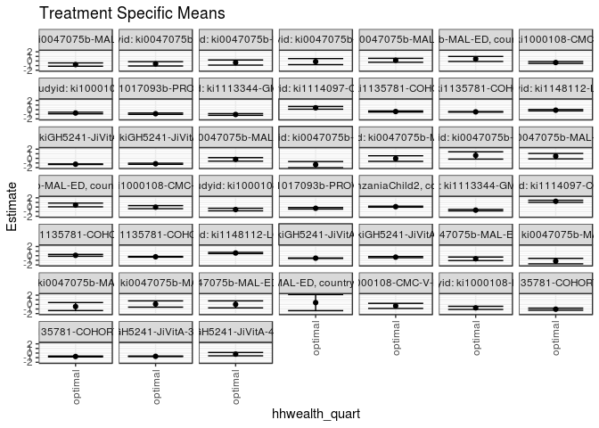

## Results Table

### Parameter: TSM

| agecat | studyid | country | intervention_level | baseline_level | estimate | ci_lower | ci_upper |
| --- | --- | --- | --- | --- | --- | --- | --- |
| Birth | ki0047075b-MAL-ED | BANGLADESH | optimal | observed | -0.6681954 | -1.0506848 | -0.2857061 |
| Birth | ki0047075b-MAL-ED | INDIA | optimal | observed | -1.1686740 | -1.7647329 | -0.5726152 |
| Birth | ki0047075b-MAL-ED | NEPAL | optimal | observed | -0.4677418 | -1.3370349 | 0.4015514 |
| Birth | ki0047075b-MAL-ED | PERU | optimal | observed | 0.0839420 | -0.5997413 | 0.7676253 |
| Birth | ki0047075b-MAL-ED | SOUTH AFRICA | optimal | observed | 0.0016584 | -0.7586806 | 0.7619974 |
| Birth | ki0047075b-MAL-ED | TANZANIA, UNITED REPUBLIC OF | optimal | observed | 0.3895843 | -1.3574051 | 2.1365736 |
| Birth | ki1000108-CMC-V-BCS-2002 | INDIA | optimal | observed | -0.3218894 | -0.8730898 | 0.2293110 |
| Birth | ki1000108-IRC | INDIA | optimal | observed | -0.7573463 | -1.0958778 | -0.4188149 |
| Birth | ki1135781-COHORTS | GUATEMALA | optimal | observed | -1.0419400 | -1.2661825 | -0.8176976 |
| Birth | ki1135781-COHORTS | PHILIPPINES | optimal | observed | -0.7412921 | -0.8331886 | -0.6493956 |
| Birth | kiGH5241-JiVitA-3 | BANGLADESH | optimal | observed | -0.7069603 | -0.7615610 | -0.6523597 |
| Birth | kiGH5241-JiVitA-4 | BANGLADESH | optimal | observed | -0.2296574 | -0.5885867 | 0.1292719 |
| 6 months | ki0047075b-MAL-ED | BANGLADESH | optimal | observed | -0.2226333 | -0.5975650 | 0.1522985 |
| 6 months | ki0047075b-MAL-ED | INDIA | optimal | observed | -1.3547292 | -2.0175056 | -0.6919527 |
| 6 months | ki0047075b-MAL-ED | NEPAL | optimal | observed | -0.0421061 | -0.6467089 | 0.5624967 |
| 6 months | ki0047075b-MAL-ED | PERU | optimal | observed | 0.6299415 | -0.1613858 | 1.4212689 |
| 6 months | ki0047075b-MAL-ED | SOUTH AFRICA | optimal | observed | 0.4754454 | -0.1139193 | 1.0648102 |
| 6 months | ki0047075b-MAL-ED | TANZANIA, UNITED REPUBLIC OF | optimal | observed | 0.4488258 | 0.0392063 | 0.8584452 |
| 6 months | ki1000108-CMC-V-BCS-2002 | INDIA | optimal | observed | -0.0264069 | -0.3593983 | 0.3065846 |
| 6 months | ki1000108-IRC | INDIA | optimal | observed | -0.5435320 | -0.8241763 | -0.2628877 |
| 6 months | ki1017093b-PROVIDE | BANGLADESH | optimal | observed | -0.2693893 | -0.4356322 | -0.1031464 |
| 6 months | ki1066203-TanzaniaChild2 | TANZANIA, UNITED REPUBLIC OF | optimal | observed | 0.0783789 | -0.0327794 | 0.1895373 |
| 6 months | ki1113344-GMS-Nepal | NEPAL | optimal | observed | -0.6720083 | -0.8321092 | -0.5119074 |
| 6 months | ki1114097-CONTENT | PERU | optimal | observed | 1.2454448 | 1.0140965 | 1.4767930 |
| 6 months | ki1135781-COHORTS | GUATEMALA | optimal | observed | 0.0853536 | -0.1183209 | 0.2890281 |
| 6 months | ki1135781-COHORTS | PHILIPPINES | optimal | observed | -0.2305143 | -0.3051704 | -0.1558582 |
| 6 months | ki1148112-LCNI-5 | MALAWI | optimal | observed | 0.5916608 | 0.4542139 | 0.7291077 |
| 6 months | kiGH5241-JiVitA-3 | BANGLADESH | optimal | observed | -0.5335561 | -0.5833715 | -0.4837406 |
| 6 months | kiGH5241-JiVitA-4 | BANGLADESH | optimal | observed | -0.3060429 | -0.4344840 | -0.1776019 |
| 24 months | ki0047075b-MAL-ED | BANGLADESH | optimal | observed | -0.7767973 | -1.1352427 | -0.4183518 |
| 24 months | ki0047075b-MAL-ED | INDIA | optimal | observed | -0.6147668 | -1.0823470 | -0.1471866 |
| 24 months | ki0047075b-MAL-ED | NEPAL | optimal | observed | -0.3369712 | -0.8966992 | 0.2227568 |
| 24 months | ki0047075b-MAL-ED | PERU | optimal | observed | -0.1326620 | -0.7898075 | 0.5244835 |
| 24 months | ki0047075b-MAL-ED | SOUTH AFRICA | optimal | observed | 0.1515975 | -0.2804220 | 0.5836171 |
| 24 months | ki0047075b-MAL-ED | TANZANIA, UNITED REPUBLIC OF | optimal | observed | 0.4491445 | -0.0924537 | 0.9907428 |
| 24 months | ki1000108-CMC-V-BCS-2002 | INDIA | optimal | observed | -0.3297807 | -0.5362223 | -0.1233391 |
| 24 months | ki1000108-IRC | INDIA | optimal | observed | -0.7225447 | -0.8990651 | -0.5460243 |
| 24 months | ki1017093b-PROVIDE | BANGLADESH | optimal | observed | -0.8781750 | -1.0212300 | -0.7351200 |
| 24 months | ki1113344-GMS-Nepal | NEPAL | optimal | observed | -1.0453058 | -1.2289646 | -0.8616470 |
| 24 months | ki1114097-CONTENT | PERU | optimal | observed | 0.4033989 | 0.1096107 | 0.6971871 |
| 24 months | ki1135781-COHORTS | GUATEMALA | optimal | observed | -0.4022526 | -0.5217570 | -0.2827483 |
| 24 months | ki1135781-COHORTS | PHILIPPINES | optimal | observed | -0.4703543 | -0.5367912 | -0.4039173 |
| 24 months | ki1148112-LCNI-5 | MALAWI | optimal | observed | -0.1105494 | -0.2607478 | 0.0396489 |
| 24 months | kiGH5241-JiVitA-3 | BANGLADESH | optimal | observed | -1.2705447 | -1.3291530 | -1.2119364 |
| 24 months | kiGH5241-JiVitA-4 | BANGLADESH | optimal | observed | -1.1726245 | -1.2904984 | -1.0547506 |

### Parameter: E(Y)

| agecat | studyid | country | intervention_level | baseline_level | estimate | ci_lower | ci_upper |
| --- | --- | --- | --- | --- | --- | --- | --- |
| Birth | ki0047075b-MAL-ED | BANGLADESH | observed | observed | -0.9414474 | -1.1655223 | -0.7173724 |
| Birth | ki0047075b-MAL-ED | INDIA | observed | observed | -1.0992593 | -1.4060416 | -0.7924769 |
| Birth | ki0047075b-MAL-ED | NEPAL | observed | observed | -0.8496667 | -1.2385841 | -0.4607492 |
| Birth | ki0047075b-MAL-ED | PERU | observed | observed | 0.0766667 | -0.2519852 | 0.4053186 |
| Birth | ki0047075b-MAL-ED | SOUTH AFRICA | observed | observed | -0.1047541 | -0.4290621 | 0.2195539 |
| Birth | ki0047075b-MAL-ED | TANZANIA, UNITED REPUBLIC OF | observed | observed | 0.5930435 | 0.1251922 | 1.0608948 |
| Birth | ki1000108-CMC-V-BCS-2002 | INDIA | observed | observed | -0.6275000 | -0.9746292 | -0.2803708 |
| Birth | ki1000108-IRC | INDIA | observed | observed | -1.0105831 | -1.1973019 | -0.8238643 |
| Birth | ki1135781-COHORTS | GUATEMALA | observed | observed | -1.2584507 | -1.4013649 | -1.1155365 |
| Birth | ki1135781-COHORTS | PHILIPPINES | observed | observed | -0.7422912 | -0.7886598 | -0.6959226 |
| Birth | kiGH5241-JiVitA-3 | BANGLADESH | observed | observed | -0.7662454 | -0.7931586 | -0.7393323 |
| Birth | kiGH5241-JiVitA-4 | BANGLADESH | observed | observed | -0.2903784 | -0.4497929 | -0.1309639 |
| 6 months | ki0047075b-MAL-ED | BANGLADESH | observed | observed | -0.2054115 | -0.4495784 | 0.0387554 |
| 6 months | ki0047075b-MAL-ED | INDIA | observed | observed | -0.7227934 | -0.9900648 | -0.4555221 |
| 6 months | ki0047075b-MAL-ED | NEPAL | observed | observed | 0.0465079 | -0.2108391 | 0.3038550 |
| 6 months | ki0047075b-MAL-ED | PERU | observed | observed | 0.8727778 | 0.5137098 | 1.2318457 |
| 6 months | ki0047075b-MAL-ED | SOUTH AFRICA | observed | observed | 0.4787179 | 0.2126042 | 0.7448317 |
| 6 months | ki0047075b-MAL-ED | TANZANIA, UNITED REPUBLIC OF | observed | observed | 0.5033333 | 0.2619074 | 0.7447593 |
| 6 months | ki1000108-CMC-V-BCS-2002 | INDIA | observed | observed | -0.5026766 | -0.6536848 | -0.3516685 |
| 6 months | ki1000108-IRC | INDIA | observed | observed | -0.5989297 | -0.7344491 | -0.4634104 |
| 6 months | ki1017093b-PROVIDE | BANGLADESH | observed | observed | -0.2080201 | -0.2927357 | -0.1233045 |
| 6 months | ki1066203-TanzaniaChild2 | TANZANIA, UNITED REPUBLIC OF | observed | observed | 0.0801680 | 0.0273223 | 0.1330136 |
| 6 months | ki1113344-GMS-Nepal | NEPAL | observed | observed | -0.6047987 | -0.6909649 | -0.5186325 |
| 6 months | ki1114097-CONTENT | PERU | observed | observed | 1.0684318 | 0.9515274 | 1.1853362 |
| 6 months | ki1135781-COHORTS | GUATEMALA | observed | observed | 0.0432727 | -0.0689069 | 0.1554524 |
| 6 months | ki1135781-COHORTS | PHILIPPINES | observed | observed | -0.2938433 | -0.3352064 | -0.2524802 |
| 6 months | ki1148112-LCNI-5 | MALAWI | observed | observed | 0.4418137 | 0.3703100 | 0.5133174 |
| 6 months | kiGH5241-JiVitA-3 | BANGLADESH | observed | observed | -0.5893545 | -0.6168122 | -0.5618967 |
| 6 months | kiGH5241-JiVitA-4 | BANGLADESH | observed | observed | -0.3684250 | -0.4392750 | -0.2975751 |
| 24 months | ki0047075b-MAL-ED | BANGLADESH | observed | observed | -0.7648701 | -0.9729655 | -0.5567748 |
| 24 months | ki0047075b-MAL-ED | INDIA | observed | observed | -0.9125352 | -1.1472376 | -0.6778328 |
| 24 months | ki0047075b-MAL-ED | NEPAL | observed | observed | -0.3526190 | -0.5782459 | -0.1269921 |
| 24 months | ki0047075b-MAL-ED | PERU | observed | observed | -0.0095312 | -0.3657847 | 0.3467222 |
| 24 months | ki0047075b-MAL-ED | SOUTH AFRICA | observed | observed | 0.3131818 | 0.1018345 | 0.5245291 |
| 24 months | ki0047075b-MAL-ED | TANZANIA, UNITED REPUBLIC OF | observed | observed | -0.0049153 | -0.2462498 | 0.2364193 |
| 24 months | ki1000108-CMC-V-BCS-2002 | INDIA | observed | observed | -0.5571505 | -0.6585247 | -0.4557763 |
| 24 months | ki1000108-IRC | INDIA | observed | observed | -0.7458150 | -0.8368180 | -0.6548120 |
| 24 months | ki1017093b-PROVIDE | BANGLADESH | observed | observed | -0.8896187 | -0.9726240 | -0.8066134 |
| 24 months | ki1113344-GMS-Nepal | NEPAL | observed | observed | -1.1315863 | -1.2192240 | -1.0439487 |
| 24 months | ki1114097-CONTENT | PERU | observed | observed | 0.5668293 | 0.4302437 | 0.7034148 |
| 24 months | ki1135781-COHORTS | GUATEMALA | observed | observed | -0.5505976 | -0.6268515 | -0.4743437 |
| 24 months | ki1135781-COHORTS | PHILIPPINES | observed | observed | -0.6099592 | -0.6467541 | -0.5731643 |
| 24 months | ki1148112-LCNI-5 | MALAWI | observed | observed | -0.0478674 | -0.1301904 | 0.0344557 |
| 24 months | kiGH5241-JiVitA-3 | BANGLADESH | observed | observed | -1.2916413 | -1.3242424 | -1.2590403 |
| 24 months | kiGH5241-JiVitA-4 | BANGLADESH | observed | observed | -1.2302244 | -1.2892920 | -1.1711567 |

### Parameter: PAR

| agecat | studyid | country | intervention_level | baseline_level | estimate | ci_lower | ci_upper |
| --- | --- | --- | --- | --- | --- | --- | --- |
| Birth | ki0047075b-MAL-ED | BANGLADESH | optimal | observed | -0.2732519 | -0.6302682 | 0.0837643 |
| Birth | ki0047075b-MAL-ED | INDIA | optimal | observed | 0.0694148 | -0.4793215 | 0.6181510 |
| Birth | ki0047075b-MAL-ED | NEPAL | optimal | observed | -0.3819249 | -1.0979405 | 0.3340907 |
| Birth | ki0047075b-MAL-ED | PERU | optimal | observed | -0.0072753 | -0.6321351 | 0.6175845 |
| Birth | ki0047075b-MAL-ED | SOUTH AFRICA | optimal | observed | -0.1064125 | -0.7304552 | 0.5176303 |
| Birth | ki0047075b-MAL-ED | TANZANIA, UNITED REPUBLIC OF | optimal | observed | 0.2034592 | -1.2568307 | 1.6637491 |
| Birth | ki1000108-CMC-V-BCS-2002 | INDIA | optimal | observed | -0.3056106 | -0.7817778 | 0.1705565 |
| Birth | ki1000108-IRC | INDIA | optimal | observed | -0.2532368 | -0.5284562 | 0.0219827 |
| Birth | ki1135781-COHORTS | GUATEMALA | optimal | observed | -0.2165107 | -0.3809224 | -0.0520989 |
| Birth | ki1135781-COHORTS | PHILIPPINES | optimal | observed | -0.0009991 | -0.0810739 | 0.0790757 |
| Birth | kiGH5241-JiVitA-3 | BANGLADESH | optimal | observed | -0.0592851 | -0.1061409 | -0.0124293 |
| Birth | kiGH5241-JiVitA-4 | BANGLADESH | optimal | observed | -0.0607209 | -0.3612363 | 0.2397945 |
| 6 months | ki0047075b-MAL-ED | BANGLADESH | optimal | observed | 0.0172218 | -0.3460125 | 0.3804560 |
| 6 months | ki0047075b-MAL-ED | INDIA | optimal | observed | 0.6319357 | 0.0361597 | 1.2277118 |
| 6 months | ki0047075b-MAL-ED | NEPAL | optimal | observed | 0.0886140 | -0.4298291 | 0.6070572 |
| 6 months | ki0047075b-MAL-ED | PERU | optimal | observed | 0.2428362 | -0.4921603 | 0.9778328 |
| 6 months | ki0047075b-MAL-ED | SOUTH AFRICA | optimal | observed | 0.0032725 | -0.5119459 | 0.5184909 |
| 6 months | ki0047075b-MAL-ED | TANZANIA, UNITED REPUBLIC OF | optimal | observed | 0.0545076 | -0.3141299 | 0.4231450 |
| 6 months | ki1000108-CMC-V-BCS-2002 | INDIA | optimal | observed | -0.4762698 | -0.7552396 | -0.1972999 |
| 6 months | ki1000108-IRC | INDIA | optimal | observed | -0.0553977 | -0.2966273 | 0.1858319 |
| 6 months | ki1017093b-PROVIDE | BANGLADESH | optimal | observed | 0.0613692 | -0.0812438 | 0.2039821 |
| 6 months | ki1066203-TanzaniaChild2 | TANZANIA, UNITED REPUBLIC OF | optimal | observed | 0.0017891 | -0.0956055 | 0.0991836 |
| 6 months | ki1113344-GMS-Nepal | NEPAL | optimal | observed | 0.0672096 | -0.0752868 | 0.2097060 |
| 6 months | ki1114097-CONTENT | PERU | optimal | observed | -0.1770130 | -0.3815957 | 0.0275696 |
| 6 months | ki1135781-COHORTS | GUATEMALA | optimal | observed | -0.0420809 | -0.2086908 | 0.1245290 |
| 6 months | ki1135781-COHORTS | PHILIPPINES | optimal | observed | -0.0633290 | -0.1281930 | 0.0015350 |
| 6 months | ki1148112-LCNI-5 | MALAWI | optimal | observed | -0.1498471 | -0.2698674 | -0.0298268 |
| 6 months | kiGH5241-JiVitA-3 | BANGLADESH | optimal | observed | -0.0557984 | -0.0957505 | -0.0158463 |
| 6 months | kiGH5241-JiVitA-4 | BANGLADESH | optimal | observed | -0.0623821 | -0.1796265 | 0.0548623 |
| 24 months | ki0047075b-MAL-ED | BANGLADESH | optimal | observed | 0.0119272 | -0.3217577 | 0.3456120 |
| 24 months | ki0047075b-MAL-ED | INDIA | optimal | observed | -0.2977684 | -0.7161495 | 0.1206126 |
| 24 months | ki0047075b-MAL-ED | NEPAL | optimal | observed | -0.0156478 | -0.4840284 | 0.4527328 |
| 24 months | ki0047075b-MAL-ED | PERU | optimal | observed | 0.1231307 | -0.5075430 | 0.7538044 |
| 24 months | ki0047075b-MAL-ED | SOUTH AFRICA | optimal | observed | 0.1615843 | -0.2213002 | 0.5444687 |
| 24 months | ki0047075b-MAL-ED | TANZANIA, UNITED REPUBLIC OF | optimal | observed | -0.4540598 | -0.9210640 | 0.0129444 |
| 24 months | ki1000108-CMC-V-BCS-2002 | INDIA | optimal | observed | -0.2273698 | -0.4036441 | -0.0510956 |
| 24 months | ki1000108-IRC | INDIA | optimal | observed | -0.0232703 | -0.1778767 | 0.1313361 |
| 24 months | ki1017093b-PROVIDE | BANGLADESH | optimal | observed | -0.0114438 | -0.1386040 | 0.1157164 |
| 24 months | ki1113344-GMS-Nepal | NEPAL | optimal | observed | -0.0862805 | -0.2444243 | 0.0718632 |
| 24 months | ki1114097-CONTENT | PERU | optimal | observed | 0.1634304 | -0.0871984 | 0.4140591 |
| 24 months | ki1135781-COHORTS | GUATEMALA | optimal | observed | -0.1483450 | -0.2404787 | -0.0562113 |
| 24 months | ki1135781-COHORTS | PHILIPPINES | optimal | observed | -0.1396049 | -0.1961469 | -0.0830629 |
| 24 months | ki1148112-LCNI-5 | MALAWI | optimal | observed | 0.0626820 | -0.0699002 | 0.1952643 |
| 24 months | kiGH5241-JiVitA-3 | BANGLADESH | optimal | observed | -0.0210966 | -0.0720464 | 0.0298532 |
| 24 months | kiGH5241-JiVitA-4 | BANGLADESH | optimal | observed | -0.0575998 | -0.1546951 | 0.0394955 |